# chapter3.Rmd

# Logistic Regression and cross validation

```r
alc <- read.table('http://s3.amazonaws.com/assets.datacamp.com/production/course_2218/datasets/alc.txt', sep=',', header = TRUE)
```

In this data set, there are 35 variables and 382 observations in total.The variables are: school,sex,age,address,famsize,Pstatus,Medu,Fedu,Mjob,Fjob reason,nursery,internet,guardian,traveltime studytime,failures,schoolsup,famsup,paid activities,higher,romantic,famrel,freetime goout,Dalc,Walc,health,absences,G1,G2,G3,alc_use,high_use.

I chose failures, absences,traveltime and activities as explainary variables to explore the relationsips between them and the target variable-high_use.The results are as below(three of them have significatly positive relationship with high_use): high_use=0.4176*failures-1.0157 high_use=0.0683*absences-1.2640 high_use=0.4290*traveltime-1.5146

So, the high_use valus will increase with the increase of failures, absences and traveltime. However, there is no significant relationship between activities and high_use.

```r
library(ggplot2)
library(tidyr)
library(dplyr)
gather(alc) %>% glimpse
```

```
## Rows: 13,370
## Columns: 2
## $ key   <chr> "school", "school", "school", "school", "school", "school", "...
## $ value <chr> "GP", "GP", "GP", "GP", "GP", "GP", "GP", "GP", "GP", "GP", "...
```

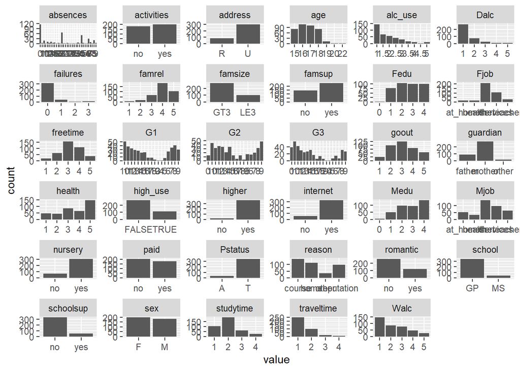

```r
gather(alc) %>% ggplot(aes(value)) + facet_wrap("key", scales = "free") + geom_bar()
```

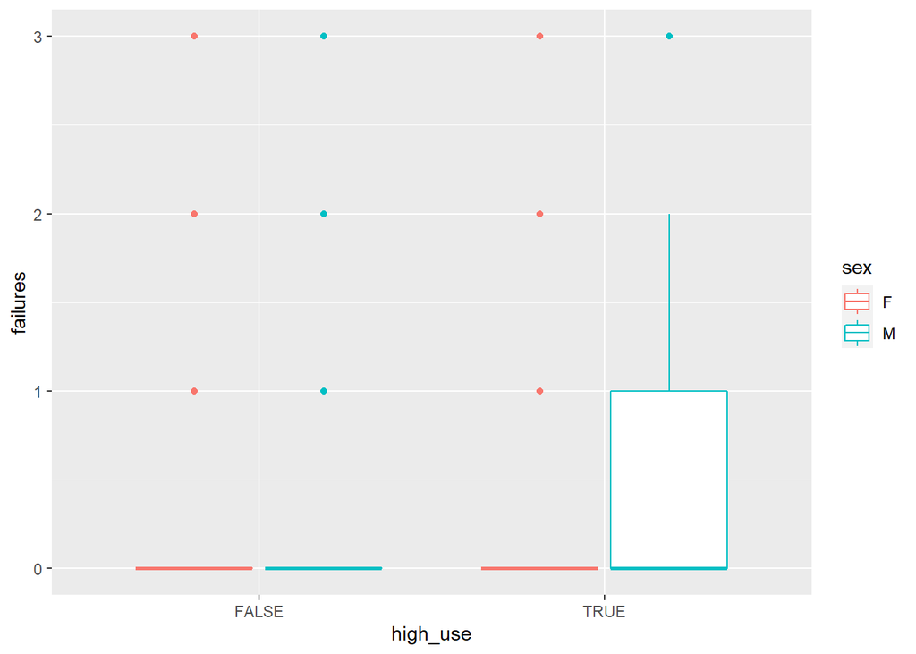

```r
g1 <- ggplot(alc, aes(x = high_use, y = failures, col = sex))
g1 + geom_boxplot() + ylab("failures")
```

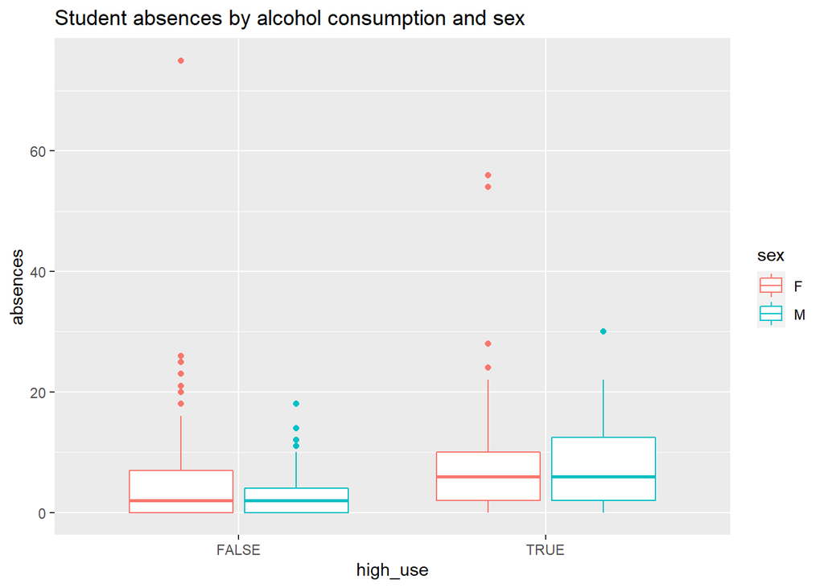

```r
g2 <- ggplot(alc, aes(x = high_use, y = absences, col = sex))
g2 + geom_boxplot() + ggtitle("Student absences by alcohol consumption and sex")
```

If we look at the combined bar chart, we can find the numbers of students who attend extra-curricular activities and the students who don’t are almost close, which can tell us the non-significat relationship between activities and high_use is sensible.Let’s use the same principle to explain the other relationships, and the results should be consistent with the original hypothese.

Based on the results of Logistic regression analysis between failures&absences&traveltime&activities and high_use, the fitted model is as below:

(Intercept) failures absences traveltime activitiesyes -1.86181552 0.36618544 0.07004812 0.42610620 -0.32180313

OR 2.5 % 97.5 % (Intercept) 0.1553903 0.0828279 0.2841262 failures 1.4422227 1.0755782 1.9361180 absences 1.0725598 1.0374448 1.1130908 traveltime 1.5312834 1.1164457 2.1057338 activitiesyes 0.7248409 0.4542950 1.1528149

high_use= 0.36619 * failures+0.07005 * absences + 0.42611 * travelime -1.86182

There is no significat relationship between activities and high_use, which is same with the previous hypothese, and should be removed fromt the whole model.

The 2x2 cross tabulation of predictions is as below:

```r
m5 <- glm(high_use ~ failures+absences+traveltime, data = alc, family = "binomial")
probabilities <- predict(m5, type = "response")
alc <- mutate(alc, probability = probabilities)
alc <- mutate(alc, prediction = probability > 0.5)
select(alc, failures, absences, traveltime, high_use, probability, prediction) %>% tail(10)
```

```
##     failures absences traveltime high_use probability prediction
## 373        1        0          2    FALSE   0.3105560      FALSE
## 374        1       14          2     TRUE   0.5424959       TRUE
## 375        0        2          2    FALSE   0.2616419      FALSE
## 376        0        7          3    FALSE   0.4322838      FALSE
## 377        1        0          1    FALSE   0.2285089      FALSE
## 378        0        0          1    FALSE   0.1686879      FALSE
## 379        1        0          2    FALSE   0.3105560      FALSE
## 380        1        0          2    FALSE   0.3105560      FALSE
## 381        0        3          2     TRUE   0.2752164      FALSE
## 382        0        0          3     TRUE   0.3194072      FALSE
```

```r
table(high_use = alc$high_use, prediction = alc$prediction)
```

```
##         prediction
## high_use FALSE TRUE
##    FALSE   260   10
##    TRUE     88   24
```

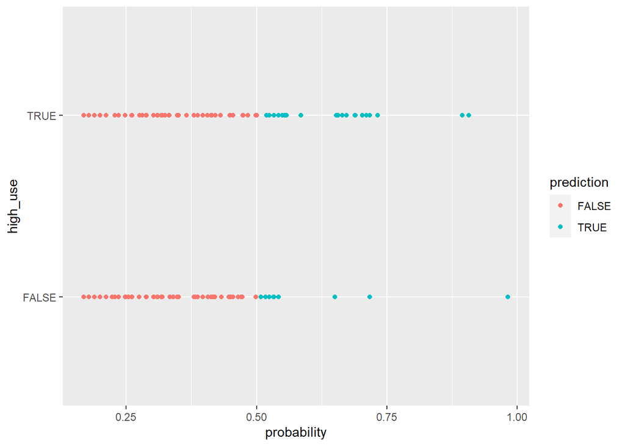

```r
g <- ggplot(alc, aes(x = probability, y = high_use, col = prediction))
g + geom_point()
```

```r
table(high_use = alc$high_use, prediction = alc$prediction) %>% prop.table %>% addmargins
```

```
##         prediction
## high_use      FALSE       TRUE        Sum
##    FALSE 0.68062827 0.02617801 0.70680628
##    TRUE  0.23036649 0.06282723 0.29319372
##    Sum   0.91099476 0.08900524 1.00000000
```

According to the 10-folds cross-validation on your mode, I got a smaller error (0.2591623) than Datacamp, which means that my model has better test set performance.

I made two different fited model with more predictors;model6 has 5 predictors which are failures,absences,traveltime,higher as well as sex; while model 7 has 4 explainary factors.

The 10 folds cross validation results are as below:

m6-> 0.2408377 m7-> 0.2382199

Compared with m5 (0.2591623), the errors of m7 is the smallest one which has one more predictor than m5.The fitted model is:

(Intercept) failures absences traveltime sexM -2.51975566 0.36718070 0.07462037 0.39558320 0.96465837

high_use= 0.36718070 * failures + 0.07462037 * absences + 0.39558320 * traveltime + 0.96465837 * sexM -2.51975566